# autoencoder

## AutoEncoders

```python
# magic for autoreloading of modules
%reload_ext autoreload
%autoreload 2

import torch
import torchvision
import torchvision.transforms as transforms

import numpy as np
import matplotlib.pyplot as plt

from torchsummary import summary
from dataset import SportBallsDataset
from utils import calculate_mean_std, plot_training_history, show_image, visualise_output
from main_ae import train_and_evaluate, reconstruct_images, interpolate_and_display
from model_ae import Autoencoder, Encoder, Decoder
```

Defining data loader for the sports ball dataset

```python
transform = transforms.Compose([transforms.ToTensor()])

dataset_ex = SportBallsDataset(root_dir='dataset', train=True, transform=transform)
dataloader_ex = torch.utils.data.DataLoader(dataset_ex, batch_size=4, shuffle=True)
```

Calculating the mean and std of the dataset per channel

```python
mean, std = calculate_mean_std(dataset_ex)
print('[Per Channel, standardised stats]')
print(' - Mean:', mean)
print(' - Standard Deviation:', std)
```

```
[Per Channel, standardised stats]
 - Mean: tensor([0.9573, 0.9379, 0.9213])
 - Standard Deviation: tensor([0.1288, 0.1431, 0.1771])
```

Define the labels

```python
classes = ("baseball", "basketball", "vollebyball", "soccerball")
classes
```

```
('baseball', 'basketball', 'vollebyball', 'soccerball')
```

Displaying some images from the dataset with their label

```
Labels:
basketball vollebyball baseball soccerball
```

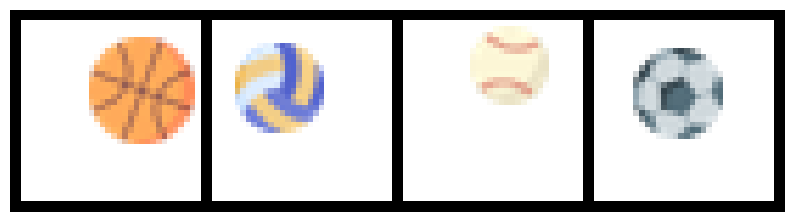

```python
# functions to show an image
def imshow(img):
    npimg = img.numpy()
    plt.figure(figsize=(10,10))
    plt.imshow(np.transpose(npimg, (1, 2, 0)))
    plt.axis('off')


# get some random training images
dataiter = iter(dataloader_ex)
images, labels = next(dataiter)

# show images
imshow(torchvision.utils.make_grid(images))

# print labels
print("Labels:")
print(' '.join('%5s' % classes[labels[j]] for j in range(4)))
```

Image normalization and conversion to tensor

```python
train_transform = transforms.Compose([
                        transforms.ToTensor(),
                        transforms.Normalize((0.9573, 0.9379, 0.9213), (0.1288, 0.1431, 0.1771))
                    ])

test_transform = transforms.Compose([
                        transforms.ToTensor(),
                        transforms.Normalize((0.9573, 0.9379, 0.9213), (0.1288, 0.1431, 0.1771))
                    ])
```

```python
train_data = SportBallsDataset(root_dir="dataset", train=True, transform=train_transform)
test_dataset = SportBallsDataset(root_dir="dataset", train=False, transform=test_transform)
```

```python
torch.manual_seed(1)
batch_size = 64

if torch.cuda.is_available():
    kwargs = {'num_workers': 4, 'pin_memory': True}
    torch.cuda.manual_seed(1)
elif torch.backends.mps.is_available():
    kwargs = {'num_workers': 4}
else:
    kwargs = {}

train_loader = torch.utils.data.DataLoader(train_data, batch_size=batch_size, shuffle=True, **kwargs)
test_loader = torch.utils.data.DataLoader(test_dataset, batch_size=batch_size, shuffle=True, **kwargs)
```

```python
# Check for available devices
if torch.cuda.is_available():
    device = torch.device("cuda")
    print("Using CUDA")
elif torch.backends.mps.is_available():
    device = torch.device("mps")
    print("Using MPS (Apple Silicon GPU)")
else:
    device = torch.device("cpu")
    print("Using CPU")
```

```
Using MPS (Apple Silicon GPU)
```

```python
encoder = Encoder(in_channels=3)
decoder = Decoder(in_channels=3)
```

Model Definition: A CNN based encoder and decoder is used in the model with latent vectors having dimension of 512.

```python
model_summary = Autoencoder(encoder=encoder, decoder=decoder, device=torch.device("cpu"))
summary(model_summary, input_size=(3, 32, 32))
```

```
----------------------------------------------------------------
        Layer (type)               Output Shape         Param #
================================================================
            Conv2d-1           [-1, 16, 32, 32]             448
              ReLU-2           [-1, 16, 32, 32]               0
            Conv2d-3           [-1, 16, 32, 32]           2,320
              ReLU-4           [-1, 16, 32, 32]               0
            Conv2d-5           [-1, 32, 16, 16]           4,640
              ReLU-6           [-1, 32, 16, 16]               0
            Conv2d-7           [-1, 32, 16, 16]           9,248
              ReLU-8           [-1, 32, 16, 16]               0
            Conv2d-9             [-1, 64, 8, 8]          18,496
             ReLU-10             [-1, 64, 8, 8]               0
           Conv2d-11             [-1, 64, 8, 8]          36,928
             ReLU-12             [-1, 64, 8, 8]               0
          Flatten-13                 [-1, 4096]               0
           Linear-14                  [-1, 512]       2,097,664
          Encoder-15                  [-1, 512]               0
           Linear-16                 [-1, 4096]       2,101,248
  ConvTranspose2d-17             [-1, 64, 8, 8]          36,928
             ReLU-18             [-1, 64, 8, 8]               0
  ConvTranspose2d-19           [-1, 32, 16, 16]          18,464
             ReLU-20           [-1, 32, 16, 16]               0
  ConvTranspose2d-21           [-1, 32, 16, 16]           9,248
             ReLU-22           [-1, 32, 16, 16]               0
  ConvTranspose2d-23           [-1, 16, 32, 32]           4,624
             ReLU-24           [-1, 16, 32, 32]               0
  ConvTranspose2d-25           [-1, 16, 32, 32]           2,320
             ReLU-26           [-1, 16, 32, 32]               0
  ConvTranspose2d-27            [-1, 3, 32, 32]             435
          Decoder-28            [-1, 3, 32, 32]               0
================================================================
Total params: 4,343,011
Trainable params: 4,343,011
Non-trainable params: 0
----------------------------------------------------------------
Input size (MB): 0.01
Forward/backward pass size (MB): 1.80
Params size (MB): 16.57
Estimated Total Size (MB): 18.38
----------------------------------------------------------------
```

```python
epochs = 20
learning_rate = 0.001
autoencoder = Autoencoder(encoder=encoder, decoder=decoder, device=device)
optimizer = torch.optim.Adam(params=autoencoder.parameters(), lr=learning_rate, weight_decay=1e-5)
```

```python
train_losses, test_losses \
    = train_and_evaluate(autoencoder, device, train_loader, test_loader, optimizer, epochs)
```

```
Train set: Average loss: 0.3981


Test set: Average loss: 0.2345
```

```
Train set: Average loss: 0.1816


Test set: Average loss: 0.1589
```

```
Train set: Average loss: 0.1193


Test set: Average loss: 0.1078
```

```
Train set: Average loss: 0.0753


Test set: Average loss: 0.0681
```

```
Train set: Average loss: 0.0628


Test set: Average loss: 0.0589
```

```
Train set: Average loss: 0.0543


Test set: Average loss: 0.0503
```

```
Train set: Average loss: 0.0488


Test set: Average loss: 0.0490
```

```
Train set: Average loss: 0.0442


Test set: Average loss: 0.0453
```

```
Train set: Average loss: 0.0424


Test set: Average loss: 0.0385
```

```
Train set: Average loss: 0.0398


Test set: Average loss: 0.0407
```

```
Train set: Average loss: 0.0374


Test set: Average loss: 0.0380
```

```
Train set: Average loss: 0.0355


Test set: Average loss: 0.0319
```

```
Train set: Average loss: 0.0333


Test set: Average loss: 0.0358
```

```
Train set: Average loss: 0.0313


Test set: Average loss: 0.0326
```

```
Train set: Average loss: 0.0298


Test set: Average loss: 0.0282
```

```
Train set: Average loss: 0.0274


Test set: Average loss: 0.0262
```

```
Train set: Average loss: 0.0255


Test set: Average loss: 0.0257
```

```
Train set: Average loss: 0.0243


Test set: Average loss: 0.0214
```

```
Train set: Average loss: 0.0233


Test set: Average loss: 0.0248
```

```
Train set: Average loss: 0.0223


Test set: Average loss: 0.0217
```

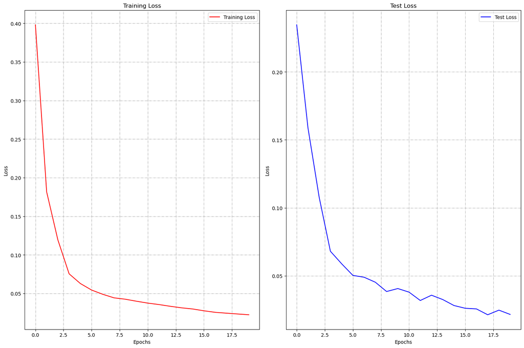

```python
plot_training_history(train_losses, test_losses)
```

The model was trained for 20 epochs with learning rate of 0.001 and MSE as loss function.

## Visualize Reconstructions

```
Original images
```

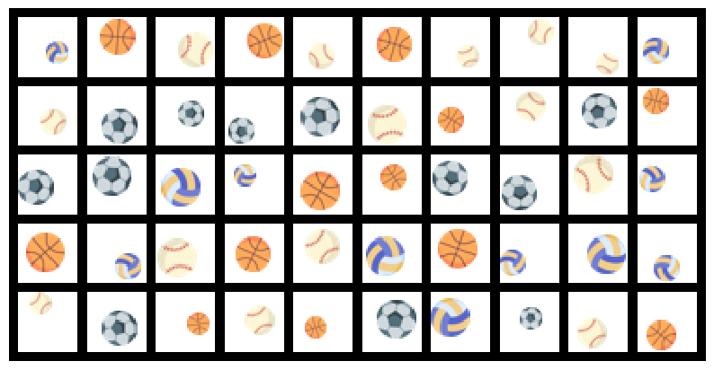

```
Clipping input data to the valid range for imshow with RGB data ([0..1] for floats or [0..255] for integers).
```

```
Autoencoder reconstruction:
```

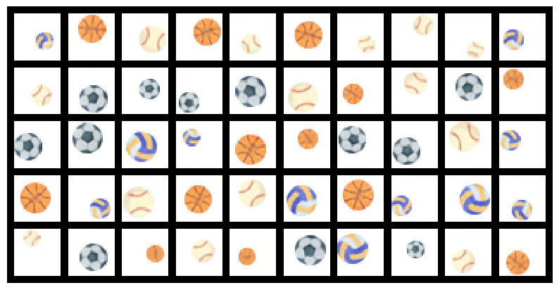

```python
images, labels = next(iter(test_loader))
num_samples = 50

print('Original images')
show_image(images[:num_samples])

# Reconstruct and visualise the images using the autoencoder
print('Autoencoder reconstruction:')
visualise_output(images, autoencoder, device, num_samples, is_vae=False)
```

## Random Latent Vector (Autoencoder as Generator)

Here latent vectors are sampled randomly from a multivariate Normal distribution fit to the distribution of data latent vectors.

Due to sampling from a fitted Normal distribution, we are in the same region of latent space as the encoded data, but even so, generating new images of the ball is hit-or-miss: many latent vectors decode to something that does not look like a ball. This means that the latent vectors that do decode to valid balls is sparse in latent space. With higher-dimensional latent spaces, the manifold gets sparser.

```
Clipping input data to the valid range for imshow with RGB data ([0..1] for floats or [0..255] for integers).
```

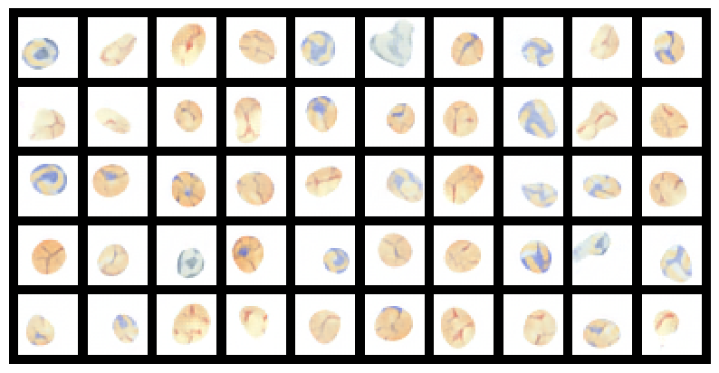

```python
# Display the reconstructed images
reconstructed_images = reconstruct_images(autoencoder, test_loader, device)
show_image(reconstructed_images[:num_samples])
```

## Interpolate in Latent Space

[figure not shown]

```python
interpolate_and_display(autoencoder, test_loader, device)
```

Saving the trained model

```python
torch.save(autoencoder.state_dict(), "model/sports_auto_encoder.pth")
```

Visualize the latent space in 2D

```python
# Switch model to evaluation mode
autoencoder.eval()

# Get latent space representations
latent_space_representations = []
labels = []

with torch.no_grad():
    for data, target in test_loader:
        data = data.to(device)
        encoded_data = autoencoder.encoder(data).cpu().numpy()
        latent_space_representations.append(encoded_data)
        labels.append(target.numpy())

latent_space_representations = np.concatenate(latent_space_representations, axis=0)
labels = np.concatenate(labels, axis=0)
```

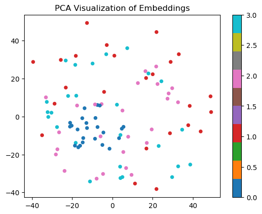

```python
from sklearn.decomposition import PCA

# Apply PCA to reduce the dimensionality to 2D
pca = PCA(n_components=2)
pca_result = pca.fit_transform(latent_space_representations)

# Plot the 2D embeddings
scatter = plt.scatter(pca_result[:, 0], pca_result[:, 1], c=labels, cmap='tab10', s=20)
plt.colorbar(scatter)
plt.title('PCA Visualization of Embeddings')
plt.show()
```